# R Notebook

```r
library(texreg)
```

Papers:

- you submit a paper
- the paper goes to editors, and decision may be as follows:
  - desk reject – not suitable for the journal (no review)
  - paper is send to reviewer (2-6 reviewers)
    - accept
    - minor corrections – revise and resubmit
    - major corrections – revise and resubmit
    - rejection

When we should use simulation studies:

- we propose a new method and we would like to show when it works and when it fails; but we may be intested in properties of such methods (what is variance, what are the standard errors of parameters, i.e. coefficients)
- we would like to simulate some population (e.g. agent-based models)
- we would like to see if given software or my own codes actually works

$$y = \beta_0 + \beta_1 x_1 + \beta_2 x_3 + \epsilon; \quad \epsilon \sim N(0, \sigma)$$

We may use pseudo-random numbers – use set.seed to reproduce results!!!

```r
set.seed(123) ## i'm specifying starting point for the algorithm that generates the data/numbers
n <- 10000 ## how many numbers we will be generating
epsilon <- rnorm(n = n, mean = 0, sd = 2) ## random numbers from N(0, 2)
x1 <- rnorm(n = n, mean = 10, sd = 3) ## pseudo-random numbers from N(10, 3)
c(mean = mean(x1), sd = sd(x1))
```

```
    mean       sd
9.972681 3.004702
```

```r
x2 <- rnorm(n = n, mean = -4, sd = 1) ## pseudo-random numbers from N(-4, 1)
y <- 0.5 - 2*x1 + 5*x2 + epsilon ## beta0 = 0.5, beta1 = -2, beta2 = 5
head(y)
```

```
[1] -59.02679 -40.06235 -52.46193 -44.28911 -46.08178 -51.18989
```

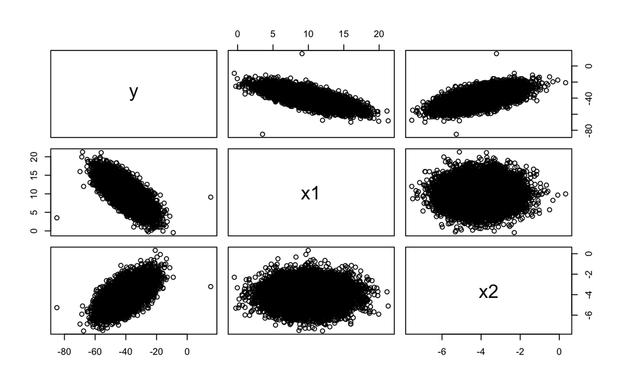

```r
y[10] <- y[10]+50
y[100] <- y[100]-50
pairs(cbind(y, x1, x2))
```

```r
data_for_model <- data.frame(y, x1, x2)
head(data_for_model, 2)
```

|  | y | x1 | x2 |
| --- | --- | --- | --- |
| 1 | -59.02679 | 17.112176 | -4.836297 |
| 2 | -40.06235 | 9.499564 | -4.220573 |

```r
m1 <- lm(formula = y ~ x1 + x2, data = data_for_model)
m2 <- lm(formula = y ~ x1, data = data_for_model)
summary(m1)
```

[output not shown]

```r
confint(m1, level = 0.95)
```

```
                 2.5 %     97.5 %
(Intercept)  0.4080475  0.8221769
x1          -2.0089854 -1.9829275
x2           5.0008441  5.0791044
```

$$y = 0.615112 -1.995956*x1 + 5.039974*x2$$

```r
screenreg(list(model1=m1, model2=m2), single.row = T)
```

```
=====================================================
             model1               model2
-----------------------------------------------------
(Intercept)      0.62 (0.11) ***    -19.53 (0.19) ***
x1              -2.00 (0.01) ***     -2.00 (0.02) ***
x2               5.04 (0.02) ***
-----------------------------------------------------
R^2              0.94                 0.55
Adj. R^2         0.94                 0.55
Num. obs.    10000                10000
=====================================================
*** p < 0.001; ** p < 0.01; * p < 0.05
```

On sample data we have predict 100% all the cases but, if we use new data (test data) – we correctly predict 50% of cases

Visual inspection of the model – why?

- residuals vs fitted – it is used to verify whether assumptions of linear model are met, in particular we verify the residuals and assumption of homoskedasticity (variance is stable)
- normal QQ – is the plot to verify assumption about normal distribution of residuals
- scale-location plot – it measures the same thing as the fist plot but it is more sensitive to not meeting the assumptions of LM
- residuals vs leverage – this plot is used to look for outliers and influential observations
  - outlier have high residual but low leverage
  - influential observeration have high leverage but low residual

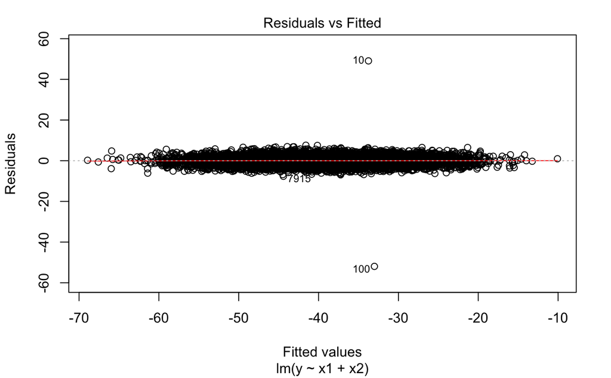

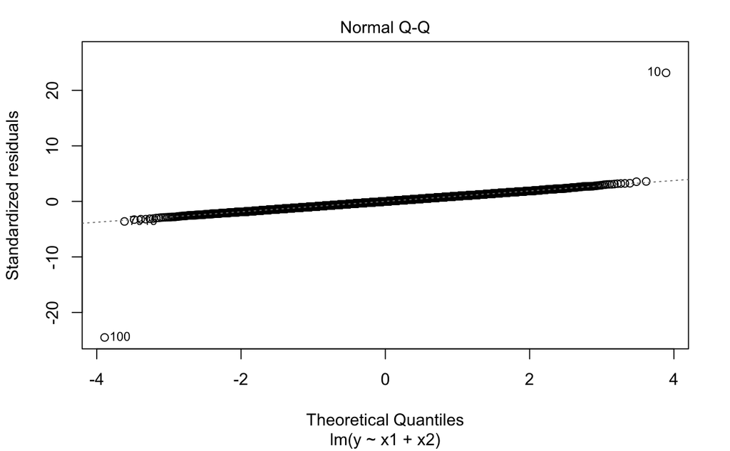

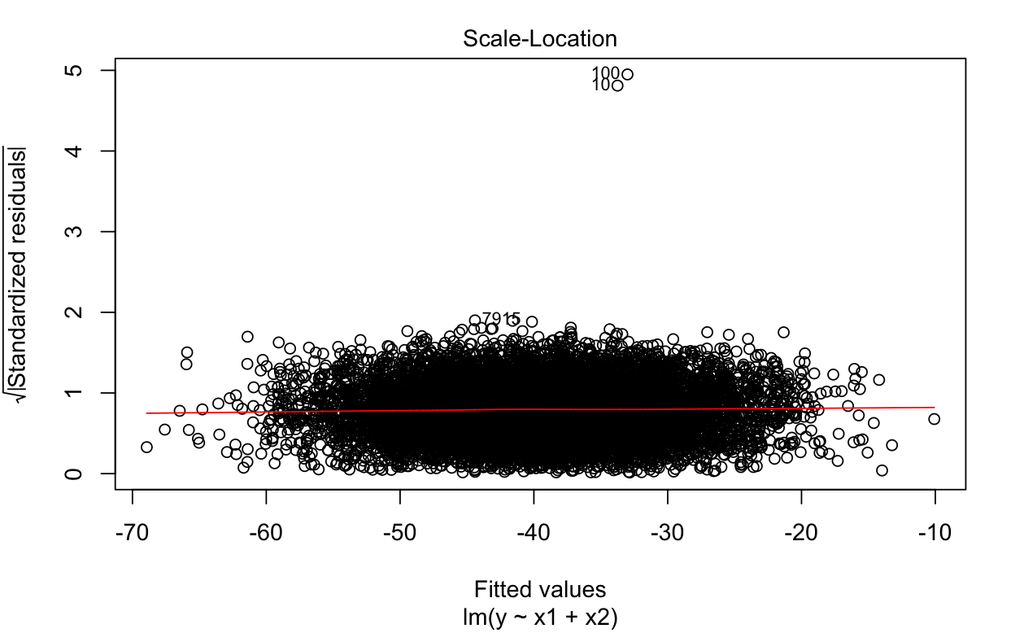

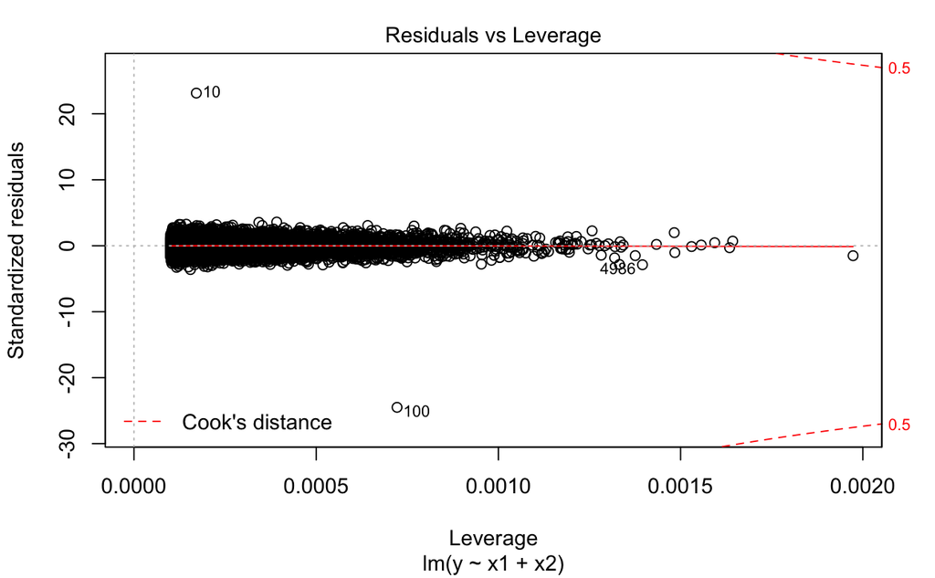

```r
plot(m1)
```

What to do if our assumptions are not met or our data have observations that are skewed or they are different from other observations but they are not errors

- use logarithm -> instead of y use log(y) -> WARNING: interpretation will change!!!

$$\begin{cases}
y & = e^{\beta_0 + \beta_1x_1} \\
log(y) & = \beta_0 + \beta_1x_1
\end{cases}$$

- use robust models (`MASS::rlm`) -> which are not effected by outliers/influential observations
- use robust standard errors –> that are robust to not meeting assumptions such as hetero or correlation of observations
- use different model (maybe non-linear model such as GLM, GAM, ML)